# Overview of data following filtering and pre-processing of downloaded studies from Recount3

Prashanthi Ravichandran

2023-10-30

This script can be used to regenerate the figures that were included in Figure 1 and Supplemental Figures 1 and 2. The required files to generate these figures are provided in our Github repo and are as follows:

1. /data/manual_annotations.tsv: Manual labels for disease, tissue and cancer status for 65404 samples from SRA
2. /data/all_counts.rds: All samples included in this study
3. /data/all_metadata.rds: Metadata labels corresponding to tissue, cancer, and source for samples from SRA, GTEx, and TCGA.
4. /data/xcellScores.rds: Precomputed xcell deconvolution scores (refer to code if you’d like to recompute)
5. /data/tsne_normal_xcell.rds: tSNE dimensionality reduction from xcell scores
6. /data/immune_tSNE.rds: tSNE dimensionality reduction from xcell scores subset to immune samples
7. /data/filter_two_fail.rds: Outliers in tissues other than immune system
8. /data/immune_samples_outlier_detection.rds: Outliers in 3 subsets of samples belonging to the immune system

### Read in processed metadata

We first read in our processed meta-data and adjust a couple of typographical errors in the tissue labeling.

```r
# Read metadata
# Specify the directory into which you have cloned the recount3 repo
homeDir <- "/data/abattle4/prashanthi/recount3_paper/"
metadata <- readRDS(paste0(homeDir, "/data/all_metadata.rds"))
metadata$tissue.category[metadata$tissue.category == "Whole_Blood"] <- "blood"
metadata$tissue.category <- gsub("_", " ", metadata$tissue.category)
metadata$tissue.category <- tolower(metadata$tissue.category)
metadata$tissue.category[metadata$tissue.category == "brain cerebellum"] <- "cerebellum"
metadata$tissue.category[metadata$tissue.category == "skeletal muscle "] <- "skeletal muscle"
metadata$tissue.category[metadata$tissue.category == "muscle skeletal"] <- "skeletal muscle"
metadata$tissue.category[metadata$tissue.category == "ipsc"] <- "ipscs"
metadata$tissue.category[metadata$tissue.category == "prostate"] <- "prostrate"
metadata$source <- metadata$study
metadata$source[grep("DRP", metadata$source)] <- "sra"
metadata$source[grep("SRP", metadata$source)] <- "sra"
metadata$source[grep("ERP", metadata$source)] <- "sra"
metadata$source[metadata$source != "sra" & metadata$source != "GTEx"] <- "TCGA"

metadata$cancer[metadata$cancer == "cancer "] <- "cancer"
metadata$cancer[metadata$cancer == ""] <- "none"
metadata$cancer[metadata$tissue.category == "cells leukemia cell line cml"] <- "cancer"
metadata <- metadata[!metadata$tissue.category == "cells leukemia cell line cml", ]

GTEx_unique_tissues <- unique(metadata$tissue.category[metadata$source == "GTEx"])
sra_unique_tissues <- unique(metadata$tissue.category[metadata$source == "sra"])
TCGA_unique_tissues <- unique(metadata$tissue.category[metadata$source == "TCGA"])

metaCounts_cancer <- data.frame("Cancer Status" = rep(unique(metadata$cancer), 3),
                        "Source" = c(rep("GTEx", 3), rep("sra", 3), rep("TCGA", 3)))
nCounts <- c()
for(i in c(1:dim(metaCounts_cancer)[1])){
  df <- metadata[metadata$source == metaCounts_cancer$Source[i], ]
  df <- df[df$cancer == metaCounts_cancer$Cancer.Status[i], ]
  nCounts[i] <- dim(df)[1]
}
metaCounts_cancer$nSamples <- nCounts
metaCounts_cancer$Cancer.Status[metaCounts_cancer$Cancer.Status == "cancer"] <- "Cancer"
metaCounts_cancer$Cancer.Status[metaCounts_cancer$Cancer.Status == "none"] <- "Non-cancerous"
metaCounts_cancer$Cancer.Status[metaCounts_cancer$Cancer.Status == "unknown"] <- "Unknown"
metaCounts_cancer$Source[metaCounts_cancer$Source == "sra"] <- "SRA"
```

### Plot Fig 1B

Obtain the visualize the number of samples from each data source that is cancerous.

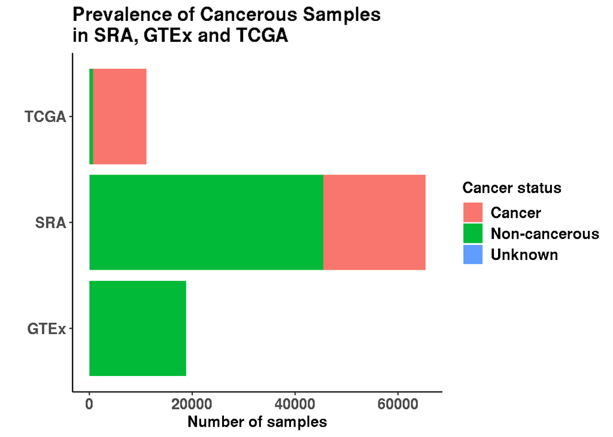

```r
p1_a <- ggplot(metaCounts_cancer,aes( x = Source, y = nSamples, fill = Cancer.Status)) + geom_bar(position="stack", stat="identity") +
theme_classic() + xlab("") + ylab("Number of samples") + coord_flip() + guides(fill=guide_legend(title="Cancer status")) +
ggtitle("Prevalence of Cancerous Samples\nin SRA, GTEx and TCGA") + theme(plot.title = element_text(face="bold", size = 16), axis.text = element_text(size = 12, face = "bold"),
                                                                          legend.text = element_text(size = 12, face = "bold"), legend.title = element_text(size = 12, face = "bold"),
                                                                          axis.title = element_text(size = 12, face = "bold"))
p1_a
```

### Plot Fig 1C

Identify most-represented tissues in each data source SRA, GTEx and TCGA, plot the number of samples from each source present in one of these top 10 most represented tissue categories

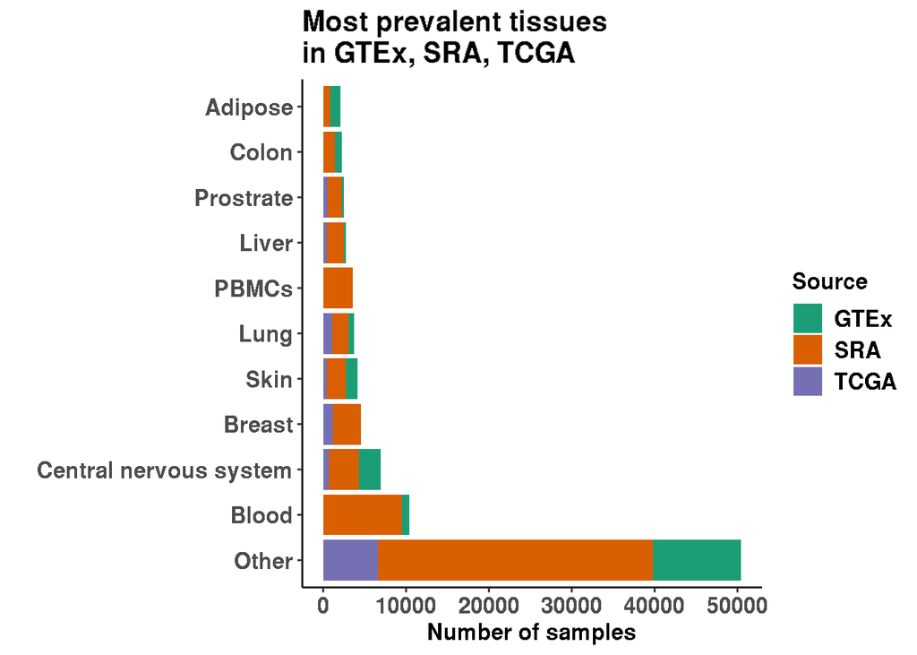

```r
tissue_freq_sra <- table(metadata$tissue.category[metadata$source == "sra"])
tissue_freq_GTEx <- table(metadata$tissue.category[metadata$source == "GTEx"])
tissue_freq_TCGA <- table(metadata$tissue.category[metadata$source == "TCGA"])

tissue_freq_sra <- data.frame(tissue_freq_sra)
tissue_freq_GTEx <- data.frame(tissue_freq_GTEx)
tissue_freq_TCGA <- data.frame(tissue_freq_TCGA)

colnames(tissue_freq_sra) <- c("Tissue", "nSamples")
colnames(tissue_freq_GTEx) <- c("Tissue", "nSamples")
colnames(tissue_freq_TCGA) <- c("Tissue", "nSamples")

tissue_freq_sra$Tissue <- as.character(tissue_freq_sra$Tissue)
tissue_freq_GTEx$Tissue <- as.character(tissue_freq_GTEx$Tissue)
tissue_freq_TCGA$Tissue <- as.character(tissue_freq_TCGA$Tissue)

tissue_freq_sra <- tissue_freq_sra[!tissue_freq_sra$Tissue == "unknown", ]

tissue_freq_sra <- tissue_freq_sra[order(tissue_freq_sra$nSamples, decreasing = TRUE), ]
tissue_freq_GTEx <- tissue_freq_GTEx[order(tissue_freq_GTEx$nSamples, decreasing = TRUE), ]
tissue_freq_TCGA <- tissue_freq_TCGA[order(tissue_freq_TCGA$nSamples, decreasing = TRUE), ]

tissue_freq_sra$Tissue <- str_to_sentence(tissue_freq_sra$Tissue)
tissue_freq_GTEx$Tissue <- str_to_sentence(tissue_freq_GTEx$Tissue)
tissue_freq_TCGA$Tissue <- str_to_sentence(tissue_freq_TCGA$Tissue)

tissue_freq_sra$Tissue[grep("Brain", tissue_freq_sra$Tissue)] <- "Central nervous system"
tissue_freq_sra$Tissue[tissue_freq_sra$Tissue == "Adipocyte"] <- "Adipose"
tissue_freq_sra$Tissue[tissue_freq_sra$Tissue == "Adipocytes"] <- "Adipose"

tissue_freq_GTEx$Tissue[grep("Brain", tissue_freq_GTEx$Tissue)] <- "Central nervous system"
tissue_freq_GTEx$Tissue[grep("Colon", tissue_freq_GTEx$Tissue)] <- "Colon"
tissue_freq_GTEx$Tissue[grep("Skin", tissue_freq_GTEx$Tissue)] <- "Skin"
tissue_freq_GTEx$Tissue[grep("Esophagus", tissue_freq_GTEx$Tissue)] <- "Esophagus"
tissue_freq_GTEx$Tissue[grep("intestine", tissue_freq_GTEx$Tissue)] <- "Intestine"
tissue_freq_GTEx$Tissue[grep("Adipose", tissue_freq_GTEx$Tissue)] <- "Adipose"
tissue_freq_GTEx$Tissue[grep("Artery", tissue_freq_GTEx$Tissue)] <- "Artery"
tissue_freq_GTEx$Tissue[grep("Heart", tissue_freq_GTEx$Tissue)] <- "Heart"
tissue_freq_GTEx$Tissue[grep("Kidney", tissue_freq_GTEx$Tissue)] <- "Kidney"

tissue_freq_TCGA$Tissue[tissue_freq_TCGA$Tissue == "Brain"] <- "Central nervous system"


tissue_freq_sra <- aggregate(tissue_freq_sra$nSamples, by=list(tissue_freq_sra$Tissue), FUN=sum)
colnames(tissue_freq_sra) <- c("Tissue", "nSamples")

tissue_freq_GTEx <- aggregate(tissue_freq_GTEx$nSamples, by=list(tissue_freq_GTEx$Tissue), FUN=sum)
colnames(tissue_freq_GTEx) <- c("Tissue", "nSamples")

tissue_freq_sra <- tissue_freq_sra[order(tissue_freq_sra$nSamples, decreasing = T), ]
tissue_freq_TCGA <- tissue_freq_TCGA[order(tissue_freq_TCGA$nSamples, decreasing = T), ]
tissue_freq_GTEx <- tissue_freq_GTEx[order(tissue_freq_GTEx$nSamples, decreasing = T), ]

tissue_freq_GTEx$Source <- "GTEx"
tissue_freq_sra$Source <- "SRA"
tissue_freq_TCGA$Source <- "TCGA"

tissue_freq <- rbind(tissue_freq_GTEx, tissue_freq_sra, tissue_freq_TCGA)
tissue_freq <- aggregate(tissue_freq$nSamples, by = list(tissue_freq$Tissue), FUN = sum)

tissue_freq <- tissue_freq[order(tissue_freq$x, decreasing = T), ]
top10_tissues <- tissue_freq$Group.1[1:10]

top10_GTEx <- tissue_freq_GTEx[tissue_freq_GTEx$Tissue %in% top10_tissues, ]
top10_TCGA <- tissue_freq_TCGA[tissue_freq_TCGA$Tissue %in% top10_tissues, ]
top10_sra <- tissue_freq_sra[tissue_freq_sra$Tissue %in% top10_tissues, ]

top10_GTEx <- rbind(top10_GTEx, data.frame("Tissue" = "Other",
                                           "nSamples" = sum(tissue_freq_GTEx$nSamples[!tissue_freq_GTEx$Tissue %in% top10_tissues]),
                                           "Source" = "GTEx"))

top10_sra <- rbind(top10_sra, data.frame("Tissue" = "Other",
                                           "nSamples" = sum(tissue_freq_sra$nSamples[!tissue_freq_sra$Tissue %in% top10_tissues]),
                                           "Source" = "SRA"))

top10_TCGA <- rbind(top10_TCGA, data.frame("Tissue" = "Other",
                                         "nSamples" = sum(tissue_freq_TCGA$nSamples[!tissue_freq_TCGA$Tissue %in% top10_tissues]),
                                         "Source" = "TCGA"))


top10_tissues_df <- rbind(top10_sra, top10_GTEx, top10_TCGA)
top10_tissues_df$Tissue[top10_tissues_df$Tissue == "Pbmcs"] <- "PBMCs"
top10_tissues[top10_tissues == "Pbmcs"] <- "PBMCs"
top10_tissues_df$Tissue <- factor(top10_tissues_df$Tissue, levels = c("Other", top10_tissues))

p1_b <- ggplot(top10_tissues_df, aes(x = Tissue, y = nSamples, fill = Source)) + geom_bar(stat = "identity", position = "stack") + ylab("Number of samples") +xlab("")+
  theme_classic() + coord_flip() + scale_fill_brewer(palette = "Dark2") + ggtitle("Most prevalent tissues\nin GTEx, SRA, TCGA") + theme(plot.title = element_text(face="bold", size = 16), axis.text = element_text(size = 12, face = "bold"),
                                                                                                                                       legend.text = element_text(size = 12, face = "bold"), legend.title = element_text(size = 12, face = "bold"),
                                                                                                                                       axis.title = element_text(size = 12, face = "bold"))

p1_b
```

### Plot Fig 1 D

Identify non-cancerous diseases present in SRA and describe the sample size of each.

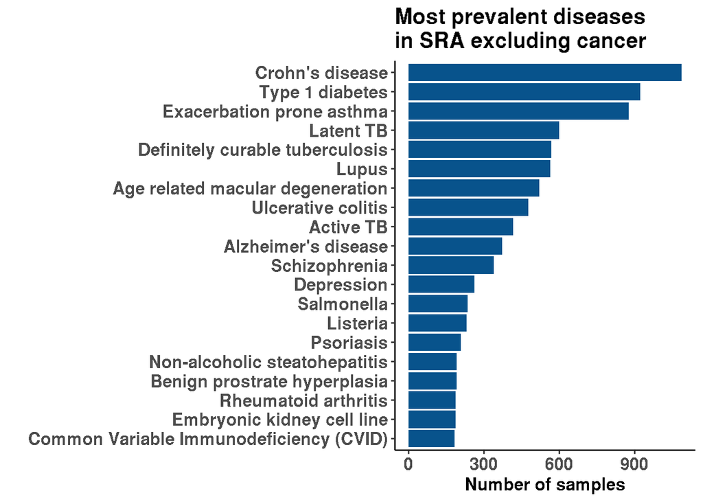

```r
# Read in disease annotations in sra
manual_annotation <- read.delim(paste0(homeDir, "data/manual_annotations.tsv"))
manual_annotation <- manual_annotation[manual_annotation$sample %in% metadata$sample, ]
manual_annotation <- manual_annotation[manual_annotation$cancer %in% c("normal", "none"), ]
disease_freq_sra <- data.frame(table(manual_annotation$disease.category))
colnames(disease_freq_sra) <- c("Disease", "nSamples")
disease_freq_sra$Disease <- str_to_sentence(disease_freq_sra$Disease)
disease_freq_sra <- disease_freq_sra[!disease_freq_sra$Disease == "Normal", ]
disease_freq_sra <- disease_freq_sra[order(disease_freq_sra$nSamples, decreasing = T), ]
disease_freq_sra <- disease_freq_sra[!disease_freq_sra$Disease == "Unknown", ]
disease_freq_sra$Disease[disease_freq_sra$Disease == "Active tb"] <- "Active TB"
disease_freq_sra$Disease[disease_freq_sra$Disease == "Latent tb"] <- "Latent TB"

disease_top20 <- disease_freq_sra[1:23, ]
disease_top20 <- disease_top20[!disease_top20$Disease == "Induced from erythroblasts", ]
disease_top20 <- disease_top20[!disease_top20$Disease == "Ebv transformed", ]
disease_top20 <- aggregate(disease_top20$nSamples, by=list(disease_top20$Disease), FUN=sum)
disease_top20 <- disease_top20[order(disease_top20$x, decreasing = F), ]
colnames(disease_top20) <- c("Disease", "nSamples")
disease_top20$Disease[disease_top20$Disease == "Common variable immunodeficiency (cvid)"] <- "Common Variable Immunodeficiency (CVID)"
disease_top20$Disease <- factor(disease_top20$Disease, levels = disease_top20$Disease)

p1_c <- ggplot(disease_top20, aes(x = Disease, y = nSamples)) + geom_bar(stat = "identity", fill = "#08538c") + ylab("Number of samples") + xlab("") +
  theme_classic() + coord_flip() + ggtitle("Most prevalent diseases\nin SRA excluding cancer")  + theme(plot.title = element_text(face="bold", size = 16), axis.text = element_text(size = 12, face = "bold"),
                                                                                      legend.text = element_text(size = 12, face = "bold"), legend.title = element_text(size = 12, face = "bold"),
                                                                                      axis.title = element_text(size = 12, face = "bold"))

p1_c
```

### Plot Fig 1 E

Read in the computed tSNE dimensionality reduction on xcell deconvolution scores to observe sample clustering by tissue category

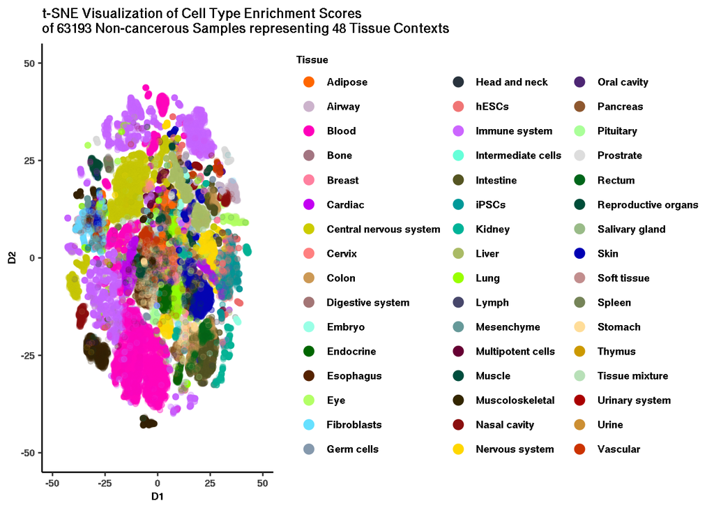

```r
metadata_cancer <- metadata[metadata$cancer == "cancer", ]
metadata_normal <- metadata[metadata$cancer == "none", ]
metadata_normal <- metadata_normal[!metadata_normal$tissue.category == "unknown", ]
metadata_cancer <- metadata_cancer[!metadata_cancer$tissue.category == "unknown", ]

counts <- readRDS(paste0(homeDir, "/data/all_counts.rds"))
counts <- t(counts)
gtex_normal <- counts[rownames(counts) %in% metadata_normal$sample[metadata_normal$source == "GTEx"], ]
gtex_cancer <- counts[rownames(counts) %in% metadata_cancer$sample[metadata_cancer$source == "GTEx"], ]
tcga_normal <- counts[rownames(counts) %in% metadata_normal$sample[metadata_normal$source == "TCGA"], ]
tcga_cancer <- counts[rownames(counts) %in% metadata_cancer$sample[metadata_cancer$source == "TCGA"], ]
sra_normal <- counts[rownames(counts) %in% metadata_normal$sample[metadata_normal$source == "sra"], ]
sra_cancer <- counts[rownames(counts) %in% metadata_cancer$sample[metadata_cancer$source == "sra"], ]

all_normal <- rbind(gtex_normal, tcga_normal, sra_normal)
all_cancer <- rbind(gtex_cancer, tcga_cancer, sra_cancer)

metadata_normal <- metadata_normal[match(rownames(all_normal), metadata_normal$sample), ]
metadata_cancer <- metadata_cancer[match(rownames(all_cancer), metadata_cancer$sample), ]

metadata_normal$tissue.category[metadata_normal$tissue.category == "smooth vessel"] <- "smooth muscle"
metadata_normal$tissue.category[metadata_normal$tissue.category == "trophoblast"] <- "trophoblasts"
metadata_normal$tissue.category[metadata_normal$tissue.category == "adipocyte"] <- "adipocytes"
tissue_palette <- read.csv(paste0(homeDir, "data/colors_clustering.csv"), header = FALSE)
plt.source.cols <- metadata_normal$source
plt.source.cols[plt.source.cols == "sra"] <- "green"
plt.source.cols[plt.source.cols == "GTEx"] <- "blue"
plt.source.cols[plt.source.cols == "TCGA"] <- "red"
plt.colors.tissues <- c()
tissue <- c()
for(i in c(1:dim(metadata_normal)[1])){
  #print(metadata_normal$tissue.category[i])
  plt.colors.tissues[i] <- tissue_palette$V2[tissue_palette$V1 == metadata_normal$tissue.category[i]]
  tissue[i] <- tissue_palette$V3[tissue_palette$V1 == metadata_normal$tissue.category[i]]
}
tissue_palette_category <- tissue_palette
tissue_palette_category$V1 <- NULL
tissue_palette_category <- distinct(tissue_palette_category, V3, .keep_all = TRUE)
rownames(tissue_palette_category) <- tissue_palette_category$V3

metadata_normal$colors <- plt.colors.tissues
metadata_normal$tissue <- tissue

plt.colors.category <- tissue_palette_category[metadata_normal$tissue, ]
plt.colors.category <- plt.colors.category$V2
plt.colors.category[metadata_normal$tissue == "Central nervous system"] <- "#EEEE00"

xcell_flag <- TRUE
if(xcell_flag){
  counts.xcellScore <- readRDS(paste0(homeDir,"data/xcellScores.rds"))
} else{
  source(paste0(homeDir, "src/xcell_sort.R"))
  metadata <- readRDS(paste0(homeDir, "data/all_metadata.rds"))
  euc.dist <- function(x1, x2) sqrt(sum((x1 - x2) ^ 2))
  geneData <- readRDS(paste0(homeDir, "data/geneData.rds"))
  geneData <- geneData[geneData$gene_id %in% rownames(counts), ]
  geneData <- geneData[match(rownames(counts), geneData$gene_id), ]
  rownames(counts) <- geneData$gene_name
  counts.xcellScore <- xCellAnalysis(counts)
  saveRDS(counts.xcellScore, paste0(homeDir, "data/xcellScores.rds"))
}

normal_xcell_scores <- counts.xcellScore[ ,metadata_normal$sample]
normal_xcell_scores <- t(normal_xcell_scores)
set.seed(100)

tsne_computed <- 1
if(tsne_computed == 1){
  tsne_normal_xcell <- readRDS(paste0(homeDir, "data/tsne_normal_xcell.rds"))
}else{
  tsne_normal_xcell <- Rtsne(normal_xcell_scores, verbose = TRUE, check_duplicates = FALSE)
  saveRDS(tsne_normal_xcell, paste0(homeDir, "data/tsne_normal_xcell.rds"))
}

normal_xcell_tsne_df <- tsne_normal_xcell$Y
normal_xcell_tsne_df <- data.frame(normal_xcell_tsne_df)
colnames(normal_xcell_tsne_df) <- c("D1", "D2")

normal_xcell_tsne_df$tissue <- metadata_normal$tissue
normal_xcell_tsne_df$tissue_subtype <- metadata_normal$tissue.category
normal_xcell_tsne_df$col_tissue <- plt.colors.category
normal_xcell_tsne_df$col_subtype <- metadata_normal$colors
normal_xcell_tsne_df$study <- metadata_normal$study
normal_xcell_tsne_df$sample_id <- metadata_normal$sample
normal_xcell_tsne_df$tissue[normal_xcell_tsne_df$tissue == "salivary gland"] <- "Salivary gland"
normal_xcell_tsne_df$tissue[normal_xcell_tsne_df$tissue == "head and neck"] <- "Head and neck"
colnames(normal_xcell_tsne_df) <- c("D1", "D2", "Tissue", "Tissue subtype", "col_tissue", "col_subtype", "Study")
normal_xcell_tsne_df$Tissue[normal_xcell_tsne_df$Tissue == "Prostate"] <- "Prostrate"
normal_xcell_tsne_df$Tissue <- as.factor(normal_xcell_tsne_df$Tissue)
tissue_palette_category <- tissue_palette_category[order(tissue_palette_category$V3), ]

p1 <- ggplot(normal_xcell_tsne_df, aes(x = D1, y = D2, color = Tissue)) +
  geom_point(alpha = 0.1) +
  scale_colour_manual(values = tissue_palette_category$V2) +
  theme_classic() + ggtitle("t-SNE Visualization of Cell Type Enrichment Scores\nof 63193 Non-cancerous Samples representing 48 Tissue Contexts") +
  guides(colour = guide_legend(ncol = 3, override.aes = list(alpha = 1, size = 3))) + xlim(c(-50, 50)) + ylim(c(-50, 50)) +
  theme(plot.title = element_text(face="bold", size = 10), axis.text = element_text(size = 8, face = "bold"),
        legend.text = element_text(size = 8, face = "bold"), legend.title = element_text(size = 8, face = "bold"),
        axis.title = element_text(size = 8, face = "bold"))
p1
```

### Plot Supp. Fig 1

Visualize outliers in each tissue cluster

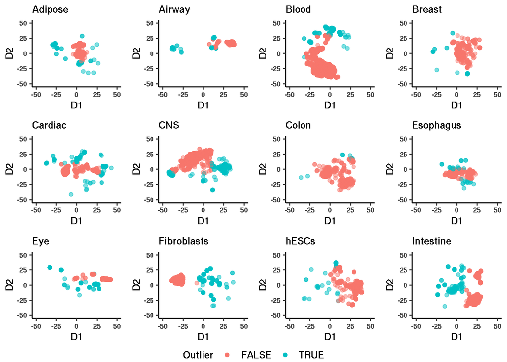

```r
outlier_annot <- readRDS(paste0(homeDir, "data/all_samples_outlier_detection.rds"))
p_list <- list()
for(i in unique(outlier_annot$tissue)){
  df <- outlier_annot[outlier_annot$tissue == i, ]
  df$z <- df$D1_z & df$D2_z
  df$mad <- df$D1_mad & df$D2_mad
  df$tukey <- df$D1_tukey & df$D2_tukey
  df$score <- rowSums(df[ ,15:20])
  df$Outlier <- df$score < 4
  p_list[[i]] <- ggplot(df, aes(x = D1, y = D2, col = Outlier)) + geom_point(alpha = 0.5) +
                 xlim(c(-50, 50)) + ylim(c(-50, 50)) + theme_classic() +
                 ggtitle(i) + guides(colour = guide_legend(override.aes = list(alpha = 1))) +                                             # Moving ggplot2 legend to the bottom
    theme(plot.title = element_text(face="bold", size = 10), axis.text = element_text(size = 8, face = "bold"),
          legend.text = element_text(size = 10, face = "bold"), legend.title = element_text(size = 10, face = "bold"),
          axis.title = element_text(size = 10, face = "bold"), legend.position = "bottom")
}
p_list[[20]] <- p_list[[20]] + ggtitle("Prostate")
p_list[[6]] <- p_list[[6]] + ggtitle("CNS")
p_list[[21]] <- p_list[[21]] + ggtitle("Musculoskeletal")


legend_outlier <- get_legend(p_list[[1]])
p_list <- lapply(p_list, function(p){
  p + theme(legend.position="none")
})


tissue_palette_category2 <- tissue_palette_category[tissue_palette_category$V3 %in% names(p_list), ]
tissue_palette_category2 <- tissue_palette_category2[order(tissue_palette_category2$V3), ]
colnames(outlier_annot)[3] <- "Tissue"
outlier_annot$Tissue <- as.factor(outlier_annot$Tissue)

p2 <- ggplot(outlier_annot, aes(x = D1, y = D2, color = Tissue)) +
  geom_point(alpha = 0.1) +
  scale_colour_manual(values = tissue_palette_category2$V2) +
  theme_classic() + ggtitle("xCell deconvolution scores (tSNE) after filtering") +
  guides(colour = guide_legend(ncol = 2, override.aes = list(alpha = 1, size = 5))) + xlim(c(-50, 50)) + ylim(c(-50, 50)) +
  theme(plot.title = element_text(face="bold", size = 16), axis.text = element_text(size = 12, face = "bold"),
        legend.text = element_text(size = 12, face = "bold"), legend.title = element_text(size = 12, face = "bold"),
        axis.title = element_text(size = 12, face = "bold"))

lay <- rbind(c(2,3,4,5),
             c(6,7,8,9),
             c(10,11,12,13),
             c(14,15,16,17),
             c(18,19,20,21),
             c(22,23,24,25),
             c(1,1,1,1))

p_list[[6]] <- p_list[[6]] + ggtitle("CNS")
p3 <- grid.arrange(legend_outlier, p_list[[1]], p_list[[2]], p_list[[3]], p_list[[4]],
                p_list[[5]], p_list[[6]], p_list[[7]], p_list[[8]],
                p_list[[9]], p_list[[10]], p_list[[11]], p_list[[12]], ncol = 4,
                layout_matrix = lay[-c(4, 5, 6), ], heights=c(4,4,4,0.5))
```

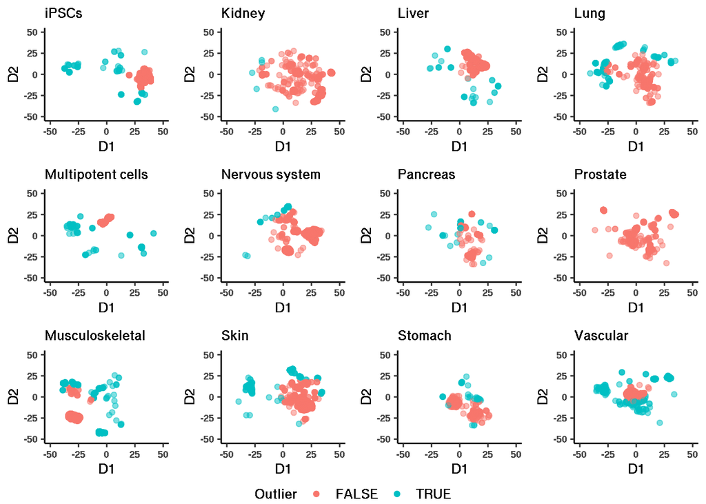

```r
p4 <- grid.arrange(legend_outlier, p_list[[13]], p_list[[14]], p_list[[15]], p_list[[16]],
                p_list[[17]], p_list[[18]], p_list[[19]], p_list[[20]],
                p_list[[21]], p_list[[22]], p_list[[23]], p_list[[24]], ncol = 4, layout_matrix = lay[-c(1, 2, 3), ],
                heights=c(4,4,4,0.5))
```

### Plot Supp. Fig 2

Visualize outliers in each cluster related to immune samples

```r
library(viridis)
```

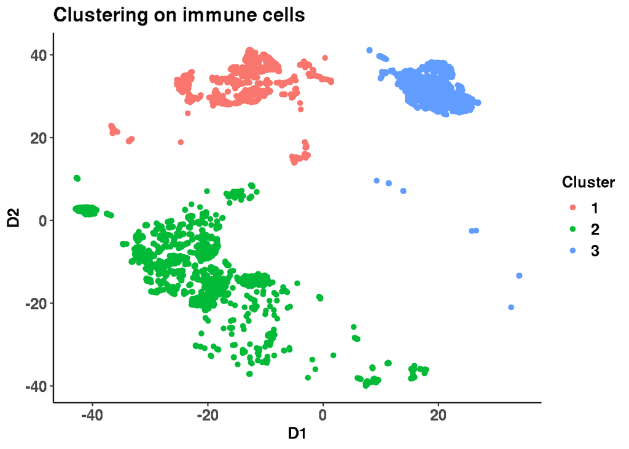

```r
df <- readRDS(paste0(homeDir, "data/immune_tSNE.rds"))
df$cluster <- as.factor(df$cluster)
colnames(df)[9] <- "Cluster"
p1 <- ggplot(df, aes(x = D1, y = D2, color = Cluster)) + geom_point() +
       theme_classic() + ggtitle("Clustering on immune cells") +
       theme(plot.title = element_text(face="bold", size = 16), axis.text = element_text(size = 12, face = "bold"),
        legend.text = element_text(size = 12, face = "bold"), legend.title = element_text(size = 12, face = "bold"),
        axis.title = element_text(size = 12, face = "bold"))

counts_cluster_1 <- data.frame(table(df$tissue_subtype[df$Cluster == 1]))
counts_cluster_1$cluster <- "1"

counts_cluster_2 <- data.frame(table(df$tissue_subtype[df$Cluster == 2]))
counts_cluster_2$cluster <- "2"

counts_cluster_3 <- data.frame(table(df$tissue_subtype[df$Cluster == 3]))
counts_cluster_3$cluster <- "3"

counts_cluster <- rbind(counts_cluster_1, counts_cluster_2, counts_cluster_3)
colnames(counts_cluster) <- c("Cell_type", "Number_of_samples", "Cluster")
counts_cluster$Cell_type <- as.character(counts_cluster$Cell_type)
counts_cluster$Cell_type[counts_cluster$Cell_type == "b cells"] <- "B cells"
counts_cluster$Cell_type[counts_cluster$Cell_type == "cells ebv-transformed lymphocytes"] <- "Cells EBV-transformed lymphocytes"
counts_cluster$Cell_type[counts_cluster$Cell_type == "dendritic cells"] <- "Dendritic cells"
counts_cluster$Cell_type[counts_cluster$Cell_type == "granulocytes"] <- "Granulocytes"
counts_cluster$Cell_type[counts_cluster$Cell_type == "lymphoblastoid"] <- "Lymphoblastoid"
counts_cluster$Cell_type[counts_cluster$Cell_type == "lymphoblastoid cell line"] <- "Lymphoblastoid cell line"
counts_cluster$Cell_type[counts_cluster$Cell_type == "lymphoid progenitors"] <- "Lymphoid progenitors"
counts_cluster$Cell_type[counts_cluster$Cell_type == "macrophage and intestinal organoid"] <- "Macrophage and intestinal organoid"
counts_cluster$Cell_type[counts_cluster$Cell_type == "macrophages"] <- "Macrophages"
counts_cluster$Cell_type[counts_cluster$Cell_type == "microglia"] <- "Microglia"
counts_cluster$Cell_type[counts_cluster$Cell_type == "monocytes"] <- "Monocytes"
counts_cluster$Cell_type[counts_cluster$Cell_type == "myeloid"] <- "Myeloid"
counts_cluster$Cell_type[counts_cluster$Cell_type == "neutrophils"] <- "Neutrophils"
counts_cluster$Cell_type[counts_cluster$Cell_type == "nk cells"] <- "NK cells"
counts_cluster$Cell_type[counts_cluster$Cell_type == "pbmcs"] <- "PBMCs"
counts_cluster$Cell_type[counts_cluster$Cell_type == "t cells"] <- "T cells"
counts_cluster$Cell_type[counts_cluster$Cell_type == "t cells (skin)"] <- "T cells (skin)"
counts_cluster$Cell_type <- as.factor(counts_cluster$Cell_type)

p2 <- ggplot(counts_cluster, aes(fill = Cell_type, y = Number_of_samples, x = Cluster)) +
  geom_bar(position="stack", stat="identity") + theme_classic() +
  xlab("Cluster") + ylab("Number of samples") + ggtitle("Cell-type prevalence in each cluster") +
  scale_fill_viridis(discrete = T) +
  guides(fill=guide_legend(ncol=2, title="Cell type")) +
  theme(plot.title = element_text(face="bold", size = 16), axis.text = element_text(size = 12, face = "bold"),
        legend.text = element_text(size = 12, face = "bold"), legend.title = element_text(size = 12, face = "bold"),
        axis.title = element_text(size = 12, face = "bold"))

p1
```

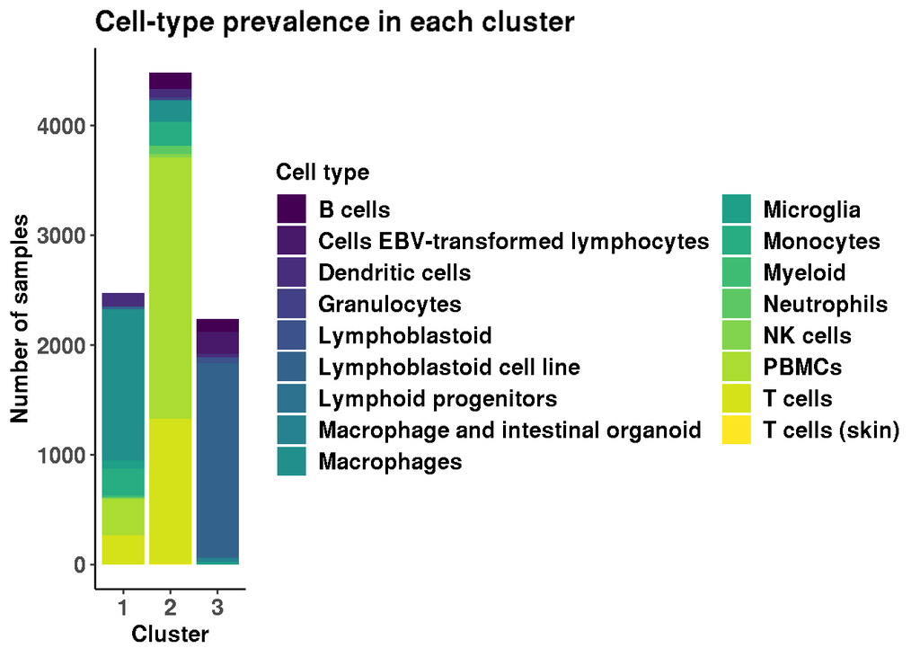

```r
p2
```

```r
immune_samples_outlier <- readRDS(paste0(homeDir, "data/immune_samples_outlier_detection.rds"))
immune_samples_outlier$z <- immune_samples_outlier$D1_z & immune_samples_outlier$D2_z
immune_samples_outlier$mad <- immune_samples_outlier$D1_mad & immune_samples_outlier$D2_mad
immune_samples_outlier$tukey <- immune_samples_outlier$D1_tukey & immune_samples_outlier$D2_tukey
immune_samples_outlier$score <- rowSums(immune_samples_outlier[ , c("z", "mad", "tukey", "maha_z", "maha_mad", "maha_tukey")])
immune_samples_outlier$Outlier <- immune_samples_outlier$score < 4

p_list <- list()
for(i in unique(immune_samples_outlier$cluster)){
  df <- immune_samples_outlier[immune_samples_outlier$cluster == i, ]
  p_list[[i]] <- ggplot(df, aes(x = D1, y = D2, color = Outlier)) + geom_point(alpha = 0.5) + theme_classic() + xlim(c(-50, 50)) + ylim(c(-50, 50)) +
    guides(colour = guide_legend(override.aes = list(alpha = 1))) +
    theme(plot.title = element_text(face="bold", size = 16), axis.text = element_text(size = 12, face = "bold"),
          legend.text = element_text(size = 12, face = "bold"), legend.title = element_text(size = 12, face = "bold"),
          axis.title = element_text(size = 12, face = "bold"), legend.position = "bottom")
}

get_legend<-function(myggplot){
  tmp <- ggplot_gtable(ggplot_build(myggplot))
  leg <- which(sapply(tmp$grobs, function(x) x$name) == "guide-box")
  legend <- tmp$grobs[[leg]]
  return(legend)
}

legend_outlier <- get_legend(p_list[[1]])
p_list <- lapply(p_list, function(p){
  p + theme(legend.position="none")
})

p_list[[1]] <- p_list[[1]] + ggtitle("Myeloid cells")
p_list[[2]] <- p_list[[2]] + ggtitle("PBMCs and T cells")
p_list[[3]] <- p_list[[3]] + ggtitle("B cells")
```

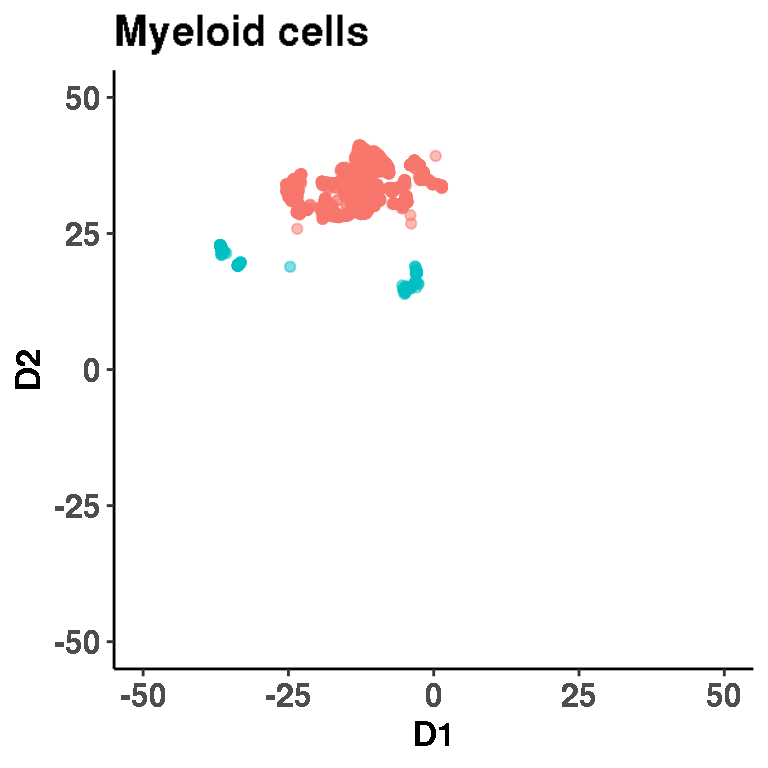

```r
p_list[[1]]
```

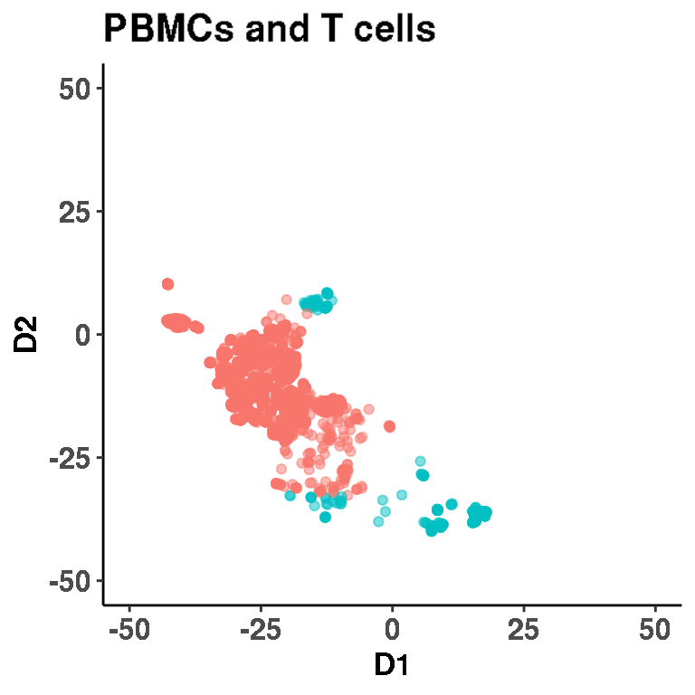

```r
p_list[[2]]
```

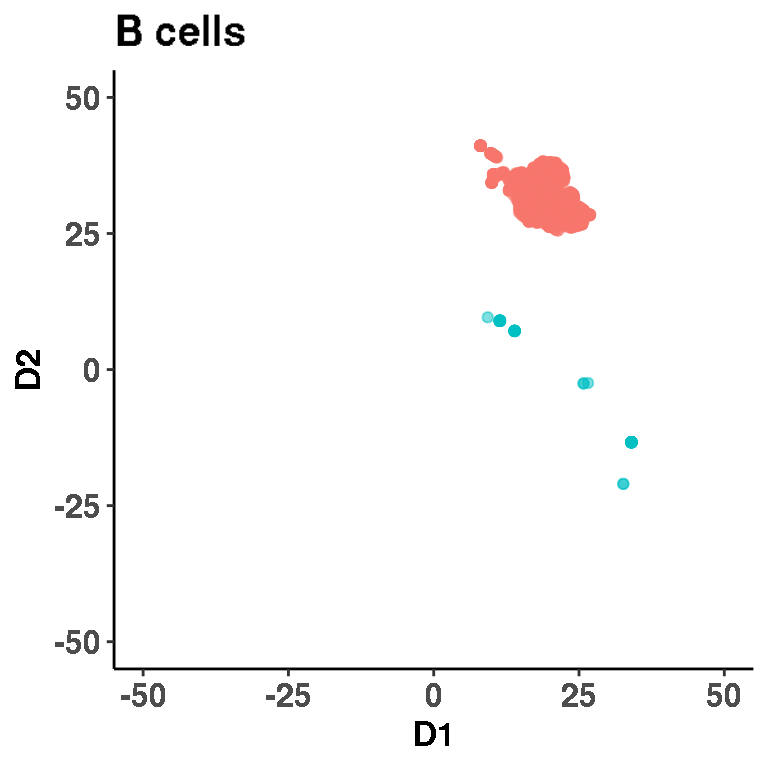

```r
p_list[[3]]
```